# mothur pipeline

Kim Dill-McFarland

version March 06, 2018

## Import the data

Create `.files` listing the full path and sample name of all the fastqs containing sequences for this project.  
`make.file(inputdir=[filePath]/Saanich, prefix=Saanich)`

## Clean-up data

Combine paired end reads into contigs using their overlapping regions.

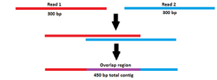

`make.contigs(file=Saanich.files, processors=10)`

Summarize the resulting contigs to see potential error, *e.g.* homopolymers, ambiguous base pairs (N), too long, too short, etc.  
`summary.seqs(fasta=Saanich.trim.contigs.fasta)`

Remove low quaility sequences.  
`screen.seqs(fasta=Saanich.trim.contigs.fasta, group=Saanich.contigs.groups, maxambig=0, maxhomop=8, minlength=200, maxlength=600)`

Determine unique sequences to reduce computational needs. Then, mothur can analysis a single sequence and apply the output to all other sequences in the data set that are identical.  
`unique.seqs(fasta=Saanich.trim.contigs.good.fasta)`

Summarize again.  
`summary.seqs(fasta=Saanich.trim.contigs.good.unique.fasta, count=Saanich.trim.contigs.good.count_table)`

Align sequences to the [SILVA database](https://www.arb-silva.de/).  
`align.seqs(fasta=Saanich.trim.contigs.good.unique.fasta, reference=/home/GLBRCORG/dillmcfarlan/mothur_files/silva.nr_v128.align, flip=T, processors=10)`

Summarize to determine the start and end sites of the data.  
`summary.seqs(fasta=Saanich.trim.contigs.good.unique.align, count=Saanich.trim.contigs.good.count_table)`

Cut the sequences to consistent start and end sites.  
`screen.seqs(fasta=Saanich.trim.contigs.good.unique.align, count=Saanich.trim.contigs.good.count_table, summary=Saanich.trim.contigs.good.unique.summary, start=10368, end=25434, processors=10)`

Remove useless alignment data like columns that are all blank or all “.”  
`filter.seqs(fasta=Saanich.trim.contigs.good.unique.good.align, vertical=T, trump=.)`

Determine unique sequences again as alignment will result in more similarity between very similar sequences.  
`unique.seqs(fasta=Saanich.trim.contigs.good.unique.good.filter.fasta, count=Saanich.trim.contigs.good.good.count_table)`

Reduce sequencing error by combining (clustering) sequences that are 3 or fewer bp different based on the general rule of 1 bp error per 100 bp sequence.  
`pre.cluster(fasta=Saanich.trim.contigs.good.unique.good.filter.unique.fasta, count=Saanich.trim.contigs.good.unique.good.filter.count_table, diffs=3)`

Summarize to few data.  
`summary.seqs(fasta=Saanich.trim.contigs.good.unique.good.filter.unique.precluster.fasta, count=Saanich.trim.contigs.good.unique.good.filter.unique.precluster.count_table)`

Identify and remove chimeric sequences.  
`chimera.uchime(fasta=Saanich.trim.contigs.good.unique.good.filter.unique.precluster.fasta, count=Saanich.trim.contigs.good.unique.good.filter.unique.precluster.count_table, dereplicate=t)`  
`remove.seqs(fasta=Saanich.trim.contigs.good.unique.good.filter.unique.precluster.fasta, count=Saanich.trim.contigs.good.unique.good.filter.unique.precluster.count_table, accnos=Saanich.trim.contigs.good.unique.good.filter.unique.precluster.denovo.uchime.accnos)`

Remove singletons, sequences that occur only once across the entire data set, as they are likely error.  
`split.abund(fasta=Saanich.trim.contigs.good.unique.good.filter.unique.precluster.pick.fasta, count=Saanich.trim.contigs.good.unique.good.filter.unique.precluster.pick.count_table, cutoff=1)`

Cope and rename the sequence (fasta) and sample data (count_table) to “final” files.  
`system(cp Saanich.trim.contigs.good.unique.good.filter.unique.precluster.pick.abund.fasta Saanich.final.fasta)`  
`system(cp Saanich.trim.contigs.good.unique.good.filter.unique.precluster.pick.abund.count_table Saanich.final.count_table)` `count.groups(count=Saanich.final.count_table)`

## Determine OTUs

Calculate distances between sequences.  
`dist.seqs(fasta=Saanich.final.fasta, processors=15)`

De novo cluster the sequences.  
`cluster.split(column=Saanich.final.dist, count=Saanich.final.count_table, method=opti, processors=10, large=T)`

Select OTUs at 97% similarity (3% difference, *e.g.* species level).  
`make.shared(list=Saanich.final.opti_mcc.unique_list.list, count=Saanich.final.count_table, label=0.03)`

## Classify OTUs

Classify all sequences using the [SILVA database](https://www.arb-silva.de/).  
`classify.seqs(fasta=Saanich.final.fasta, count=Saanich.final.count_table, template=/home/GLBRCORG/dillmcfarlan/mothur_files/silva.nr_v128.align, taxonomy=/home/GLBRCORG/dillmcfarlan/mothur_files/silva.nr_v128.tax, cutoff=80, processors=10)`

Condense these taxonomies for each OTU.  
`classify.otu(list=Saanich.final.opti_mcc.unique_list.list, taxonomy=Saanich.final.nr_v128.wang.taxonomy, count=Saanich.final.count_table, label=0.03, cutoff=80, basis=otu, probs=F)`

## Create phyloseq object

We will create a phyloseq object containing the following, so these data need to be in the correct form for phyloseq.

- OTU table
- Taxonomy
- Sample metadata

Load necessary packages.

```r
library(phyloseq)
library(tidyverse)
```

Import data

```r
OTU = read.table("Saanich.final.opti_mcc.unique_list.shared", sep="\t", header=TRUE, row.names=2)
### See how we can designate column 2 as row names instead of the normal use of column 1

taxonomy = read.table("Saanich.final.opti_mcc.unique_list.0.03.cons.taxonomy", sep="\t", header=TRUE, row.names=1)

metadata = read.table("Saanich.metadata.txt", sep="\t", header=TRUE, row.names=1)
```

If we look at the data from mothur (OTU and taxonomy), they are not perfectly setup so we need to manipulate them a little with the tidyverse.

#### OTU table clean-up

- Remove extra columns “label” and “numOtus”

```r
OTU.clean = OTU %>%
  select(-label, -numOtus)
```

#### Taxonomy table clean-up

- Remove extra column “Size”
- Separate taxonomy into 1 column per level
- Name taxonomy columns by level

```r
taxonomy.clean = taxonomy %>%
  select(-Size) %>%
  separate(Taxonomy, c("Domain", "Phylum", "Class", "Order", "Family", "Genus", "Species"), sep=";")
```

#### Define parts of the phyloseq object.

Phyloseq has very specific formatting so we need to use its functions to tell it exactly what sort of data each of our data frames are.

```r
OTU.clean.physeq = otu_table(as.matrix(OTU.clean), taxa_are_rows=FALSE)
tax.clean.physeq = tax_table(as.matrix(taxonomy.clean))
metadata.physeq = sample_data(metadata)
```

#### Create and save phyloseq object

Then we merge all the pieces into 1 phyloseq object.

```r
mothur = phyloseq(OTU.clean.physeq, tax.clean.physeq, metadata.physeq)
```

Now we have a lot of intermediate files and dataframes in our R environment. Instead of saving the entire environment, we will specifically save just our `mothur` phyloseq object for use in the projects.

```r
save(mothur, file="mothur_phyloseq.RData")
```